# SVM_on_Heart_Disease_Failure_Prediction

**Importing Library**

```python
import numpy as np
import pandas as pd
import matplotlib.pyplot as plt
import seaborn as sns
import os
import warnings
```

**Data Preparation**

```python
data = pd.read_csv('heart.csv')
```

```python
data
```

|  | Age | Sex | ChestPainType | RestingBP | Cholesterol | FastingBS | RestingECG | MaxHR | ExerciseAngina | Oldpeak | ST_Slope | HeartDisease |
| --- | --- | --- | --- | --- | --- | --- | --- | --- | --- | --- | --- | --- |
| 0 | 40 | M | ATA | 140 | 289 | 0 | Normal | 172 | N | 0.0 | Up | 0 |
| 1 | 49 | F | NAP | 160 | 180 | 0 | Normal | 156 | N | 1.0 | Flat | 1 |
| 2 | 37 | M | ATA | 130 | 283 | 0 | ST | 98 | N | 0.0 | Up | 0 |
| 3 | 48 | F | ASY | 138 | 214 | 0 | Normal | 108 | Y | 1.5 | Flat | 1 |
| 4 | 54 | M | NAP | 150 | 195 | 0 | Normal | 122 | N | 0.0 | Up | 0 |
| ... | ... | ... | ... | ... | ... | ... | ... | ... | ... | ... | ... | ... |
| 913 | 45 | M | TA | 110 | 264 | 0 | Normal | 132 | N | 1.2 | Flat | 1 |
| 914 | 68 | M | ASY | 144 | 193 | 1 | Normal | 141 | N | 3.4 | Flat | 1 |
| 915 | 57 | M | ASY | 130 | 131 | 0 | Normal | 115 | Y | 1.2 | Flat | 1 |
| 916 | 57 | F | ATA | 130 | 236 | 0 | LVH | 174 | N | 0.0 | Flat | 1 |
| 917 | 38 | M | NAP | 138 | 175 | 0 | Normal | 173 | N | 0.0 | Up | 0 |

918 rows × 12 columns

**Checking Null values**

```python
data.isnull().sum()
```

```
Age               0
Sex               0
ChestPainType     0
RestingBP         0
Cholesterol       0
FastingBS         0
RestingECG        0
MaxHR             0
ExerciseAngina    0
Oldpeak           0
ST_Slope          0
HeartDisease      0
dtype: int64
```

**Finding Correlation for Every Numerical Features**

```python
#correlation table
correlation = data.corr()
correlation.style\
    .background_gradient(cmap='bwr')\
    .set_precision(2)
```

|  | Age | RestingBP | Cholesterol | FastingBS | MaxHR | Oldpeak | HeartDisease |
| --- | --- | --- | --- | --- | --- | --- | --- |
| Age | 1.00 | 0.25 | -0.10 | 0.20 | -0.38 | 0.26 | 0.28 |
| RestingBP | 0.25 | 1.00 | 0.10 | 0.07 | -0.11 | 0.16 | 0.11 |
| Cholesterol | -0.10 | 0.10 | 1.00 | -0.26 | 0.24 | 0.05 | -0.23 |
| FastingBS | 0.20 | 0.07 | -0.26 | 1.00 | -0.13 | 0.05 | 0.27 |
| MaxHR | -0.38 | -0.11 | 0.24 | -0.13 | 1.00 | -0.16 | -0.40 |
| Oldpeak | 0.26 | 0.16 | 0.05 | 0.05 | -0.16 | 1.00 | 0.40 |
| HeartDisease | 0.28 | 0.11 | -0.23 | 0.27 | -0.40 | 0.40 | 1.00 |

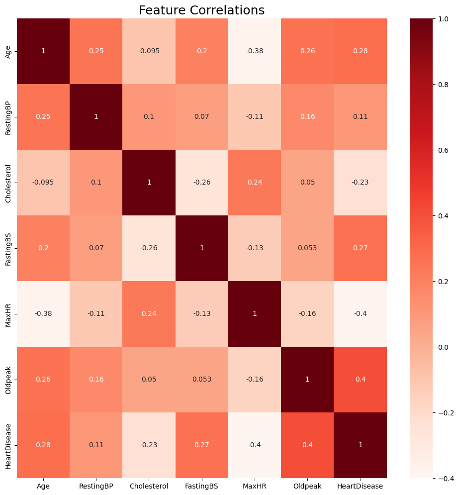

```python
#Using Seaborn heatmap visualization
plt.figure(figsize = (12, 12))
plt.title("Feature Correlations", fontsize = 18)
sns.heatmap(correlation, annot = True, cmap = "Reds")
```

**Interpretion:** The relationship of each characteristic with heart disease is not considerably different. We then examine the Variance Inflation Factor (VIF) for colinearity.

**Variance Inflation Factor**

```python
from statsmodels.stats.outliers_influence import variance_inflation_factor
vif = pd.DataFrame()
numeric_ds = data.select_dtypes(['number'])
vif["features"] = numeric_ds.columns
vif["VIF"] = [variance_inflation_factor(numeric_ds.values, i) for i in range(numeric_ds.shape[1])]
vif
```

|  | features | VIF |
| --- | --- | --- |
| 0 | Age | 30.462968 |
| 1 | RestingBP | 43.070748 |
| 2 | Cholesterol | 5.106418 |
| 3 | FastingBS | 1.500987 |
| 4 | MaxHR | 20.458949 |
| 5 | Oldpeak | 2.122029 |
| 6 | HeartDisease | 3.222266 |

*VIF is high for restingBP, age, and MaxHR*. It shows colinearity in those three aspects. As a result, we drop the highest VIF (RestingBP) and calculate the VIF.

```python
numeric_ds = numeric_ds.drop('RestingBP', axis=1)
vif.drop(vif.index, inplace=True)
vif["features"] = numeric_ds.columns
vif["VIF"] = [variance_inflation_factor(numeric_ds.values, i) for i in range(numeric_ds.shape[1])]
vif
```

|  | features | VIF |
| --- | --- | --- |
| 0 | Age | 17.294587 |
| 1 | Cholesterol | 4.960139 |
| 2 | FastingBS | 1.500343 |
| 3 | MaxHR | 14.889208 |
| 4 | Oldpeak | 2.121690 |
| 5 | HeartDisease | 3.151320 |

We can see that the **VIF is decreased after droping the RestingBP**. Now let's try by dropping the age and calculate the VIF

```python
numeric_ds = numeric_ds.drop('Age', axis=1)
vif.drop(vif.index, inplace=True)
vif["features"] = numeric_ds.columns
vif["VIF"] = [variance_inflation_factor(numeric_ds.values, i) for i in range(numeric_ds.shape[1])]
vif
```

|  | features | VIF |
| --- | --- | --- |
| 0 | Cholesterol | 4.846509 |
| 1 | FastingBS | 1.455528 |
| 2 | MaxHR | 6.048800 |
| 3 | Oldpeak | 2.077846 |
| 4 | HeartDisease | 2.651516 |

We got an acceptable VIF after dropping RestingBP and Age. It does certainly provide comparable data between Age, RestingBP, and MaxHR. It is natural for someone's resting blood pressure and heart rate to vary with age. As a result, we remove those two characteristics from our core dataset.

```python
data = data.drop(['Age', 'RestingBP'], axis=1)
data
```

|  | Sex | ChestPainType | Cholesterol | FastingBS | RestingECG | MaxHR | ExerciseAngina | Oldpeak | ST_Slope | HeartDisease |
| --- | --- | --- | --- | --- | --- | --- | --- | --- | --- | --- |
| 0 | M | ATA | 289 | 0 | Normal | 172 | N | 0.0 | Up | 0 |
| 1 | F | NAP | 180 | 0 | Normal | 156 | N | 1.0 | Flat | 1 |
| 2 | M | ATA | 283 | 0 | ST | 98 | N | 0.0 | Up | 0 |
| 3 | F | ASY | 214 | 0 | Normal | 108 | Y | 1.5 | Flat | 1 |
| 4 | M | NAP | 195 | 0 | Normal | 122 | N | 0.0 | Up | 0 |
| ... | ... | ... | ... | ... | ... | ... | ... | ... | ... | ... |
| 913 | M | TA | 264 | 0 | Normal | 132 | N | 1.2 | Flat | 1 |
| 914 | M | ASY | 193 | 1 | Normal | 141 | N | 3.4 | Flat | 1 |
| 915 | M | ASY | 131 | 0 | Normal | 115 | Y | 1.2 | Flat | 1 |
| 916 | F | ATA | 236 | 0 | LVH | 174 | N | 0.0 | Flat | 1 |
| 917 | M | NAP | 175 | 0 | Normal | 173 | N | 0.0 | Up | 0 |

918 rows × 10 columns

**Encoding Categorical Features**

```python
data.select_dtypes(exclude="number").nunique()
```

```
Sex               2
ChestPainType     4
RestingECG        3
ExerciseAngina    2
ST_Slope          3
dtype: int64
```

There are five features that have to be encoded.Sex and Exercise Angina can apply label encoding, whereas the rest can use a single hot encoding.

```python
from sklearn.preprocessing import LabelEncoder
le = LabelEncoder()
data['Sex']=le.fit_transform(data['Sex'])
data['ExerciseAngina']=le.fit_transform(data['ExerciseAngina'])
data
```

|  | Sex | ChestPainType | Cholesterol | FastingBS | RestingECG | MaxHR | ExerciseAngina | Oldpeak | ST_Slope | HeartDisease |
| --- | --- | --- | --- | --- | --- | --- | --- | --- | --- | --- |
| 0 | 1 | ATA | 289 | 0 | Normal | 172 | 0 | 0.0 | Up | 0 |
| 1 | 0 | NAP | 180 | 0 | Normal | 156 | 0 | 1.0 | Flat | 1 |
| 2 | 1 | ATA | 283 | 0 | ST | 98 | 0 | 0.0 | Up | 0 |
| 3 | 0 | ASY | 214 | 0 | Normal | 108 | 1 | 1.5 | Flat | 1 |
| 4 | 1 | NAP | 195 | 0 | Normal | 122 | 0 | 0.0 | Up | 0 |
| ... | ... | ... | ... | ... | ... | ... | ... | ... | ... | ... |
| 913 | 1 | TA | 264 | 0 | Normal | 132 | 0 | 1.2 | Flat | 1 |
| 914 | 1 | ASY | 193 | 1 | Normal | 141 | 0 | 3.4 | Flat | 1 |
| 915 | 1 | ASY | 131 | 0 | Normal | 115 | 1 | 1.2 | Flat | 1 |
| 916 | 0 | ATA | 236 | 0 | LVH | 174 | 0 | 0.0 | Flat | 1 |
| 917 | 1 | NAP | 175 | 0 | Normal | 173 | 0 | 0.0 | Up | 0 |

918 rows × 10 columns

- Encoded Sex to : 1 if Male, 0 if Female,
- Encoded ExerciseAngina to : 1 if Yes, 0 if No.

```python
dataset = pd.get_dummies(data, drop_first=False)
dataset
```

|  | Sex | Cholesterol | FastingBS | MaxHR | ExerciseAngina | Oldpeak | HeartDisease | ChestPainType_ASY | ChestPainType_ATA | ChestPainType_NAP | ChestPainType_TA | RestingECG_LVH | RestingECG_Normal | RestingECG_ST | ST_Slope_Down | ST_Slope_Flat | ST_Slope_Up |
| --- | --- | --- | --- | --- | --- | --- | --- | --- | --- | --- | --- | --- | --- | --- | --- | --- | --- |
| 0 | 1 | 289 | 0 | 172 | 0 | 0.0 | 0 | 0 | 1 | 0 | 0 | 0 | 1 | 0 | 0 | 0 | 1 |
| 1 | 0 | 180 | 0 | 156 | 0 | 1.0 | 1 | 0 | 0 | 1 | 0 | 0 | 1 | 0 | 0 | 1 | 0 |
| 2 | 1 | 283 | 0 | 98 | 0 | 0.0 | 0 | 0 | 1 | 0 | 0 | 0 | 0 | 1 | 0 | 0 | 1 |
| 3 | 0 | 214 | 0 | 108 | 1 | 1.5 | 1 | 1 | 0 | 0 | 0 | 0 | 1 | 0 | 0 | 1 | 0 |
| 4 | 1 | 195 | 0 | 122 | 0 | 0.0 | 0 | 0 | 0 | 1 | 0 | 0 | 1 | 0 | 0 | 0 | 1 |
| ... | ... | ... | ... | ... | ... | ... | ... | ... | ... | ... | ... | ... | ... | ... | ... | ... | ... |
| 913 | 1 | 264 | 0 | 132 | 0 | 1.2 | 1 | 0 | 0 | 0 | 1 | 0 | 1 | 0 | 0 | 1 | 0 |
| 914 | 1 | 193 | 1 | 141 | 0 | 3.4 | 1 | 1 | 0 | 0 | 0 | 0 | 1 | 0 | 0 | 1 | 0 |
| 915 | 1 | 131 | 0 | 115 | 1 | 1.2 | 1 | 1 | 0 | 0 | 0 | 0 | 1 | 0 | 0 | 1 | 0 |
| 916 | 0 | 236 | 0 | 174 | 0 | 0.0 | 1 | 0 | 1 | 0 | 0 | 1 | 0 | 0 | 0 | 1 | 0 |
| 917 | 1 | 175 | 0 | 173 | 0 | 0.0 | 0 | 0 | 0 | 1 | 0 | 0 | 1 | 0 | 0 | 0 | 1 |

918 rows × 17 columns

Single-Hot Encoded the remaining categorical features.

**Reordering the Dataset**

```python
heart_dis = dataset['HeartDisease']
dataset = dataset.drop('HeartDisease', axis=1)
dataset.insert(loc=len(dataset.columns), column='HeartDisease', value=heart_dis)
dataset
```

|  | Sex | Cholesterol | FastingBS | MaxHR | ExerciseAngina | Oldpeak | ChestPainType_ASY | ChestPainType_ATA | ChestPainType_NAP | ChestPainType_TA | RestingECG_LVH | RestingECG_Normal | RestingECG_ST | ST_Slope_Down | ST_Slope_Flat | ST_Slope_Up | HeartDisease |
| --- | --- | --- | --- | --- | --- | --- | --- | --- | --- | --- | --- | --- | --- | --- | --- | --- | --- |
| 0 | 1 | 289 | 0 | 172 | 0 | 0.0 | 0 | 1 | 0 | 0 | 0 | 1 | 0 | 0 | 0 | 1 | 0 |
| 1 | 0 | 180 | 0 | 156 | 0 | 1.0 | 0 | 0 | 1 | 0 | 0 | 1 | 0 | 0 | 1 | 0 | 1 |
| 2 | 1 | 283 | 0 | 98 | 0 | 0.0 | 0 | 1 | 0 | 0 | 0 | 0 | 1 | 0 | 0 | 1 | 0 |
| 3 | 0 | 214 | 0 | 108 | 1 | 1.5 | 1 | 0 | 0 | 0 | 0 | 1 | 0 | 0 | 1 | 0 | 1 |
| 4 | 1 | 195 | 0 | 122 | 0 | 0.0 | 0 | 0 | 1 | 0 | 0 | 1 | 0 | 0 | 0 | 1 | 0 |
| ... | ... | ... | ... | ... | ... | ... | ... | ... | ... | ... | ... | ... | ... | ... | ... | ... | ... |
| 913 | 1 | 264 | 0 | 132 | 0 | 1.2 | 0 | 0 | 0 | 1 | 0 | 1 | 0 | 0 | 1 | 0 | 1 |
| 914 | 1 | 193 | 1 | 141 | 0 | 3.4 | 1 | 0 | 0 | 0 | 0 | 1 | 0 | 0 | 1 | 0 | 1 |
| 915 | 1 | 131 | 0 | 115 | 1 | 1.2 | 1 | 0 | 0 | 0 | 0 | 1 | 0 | 0 | 1 | 0 | 1 |
| 916 | 0 | 236 | 0 | 174 | 0 | 0.0 | 0 | 1 | 0 | 0 | 1 | 0 | 0 | 0 | 1 | 0 | 1 |
| 917 | 1 | 175 | 0 | 173 | 0 | 0.0 | 0 | 0 | 1 | 0 | 0 | 1 | 0 | 0 | 0 | 1 | 0 |

918 rows × 17 columns

Re-order the HeartDisease column into the rightmost of the dataset to mark it as the dependant variable from the dataset. Now we're ready for the classification model building.

**Data Preprocessing**

**Transforming Dataset into Array**

```python
x = dataset.iloc[:, :-1].values
y = dataset.iloc[:, -1].values
```

```python
print(x)
```

```
[[  1. 289.   0. ...   0.   0.   1.]
 [  0. 180.   0. ...   0.   1.   0.]
 [  1. 283.   0. ...   0.   0.   1.]
 ...
 [  1. 131.   0. ...   0.   1.   0.]
 [  0. 236.   0. ...   0.   1.   0.]
 [  1. 175.   0. ...   0.   0.   1.]]
```

```python
print(y)
```

```
[0 1 0 1 0 0 0 0 1 0 0 1 0 1 0 0 1 0 1 1 0 0 0 1 0 0 0 0 0 0 1 0 1 1 0 0 1
 0 0 0 0 1 0 0 1 0 0 0 0 1 1 1 0 0 0 0 1 1 0 1 0 0 0 1 0 0 0 0 1 0 1 0 1 0
 1 0 1 0 0 1 0 0 1 0 1 1 1 0 1 0 0 0 0 1 0 1 0 0 0 0 1 0 1 1 1 0 0 0 0 0 0
 1 0 0 0 1 1 1 0 1 1 0 0 1 0 0 0 0 0 0 0 1 1 1 0 1 0 0 1 1 1 1 1 0 1 0 0 0
 0 1 0 0 0 0 0 1 1 0 1 0 1 1 0 0 0 1 1 0 0 0 0 0 0 0 1 1 1 0 0 0 1 0 1 0 0
 1 0 1 0 1 0 0 0 0 0 0 0 0 1 0 0 0 0 0 0 0 0 1 0 1 1 1 0 0 1 0 1 0 0 0 1 1
 0 0 0 1 0 1 0 0 0 0 0 0 0 0 1 1 1 1 0 1 1 0 1 0 1 1 1 1 1 1 0 0 1 0 0 0 0
 0 0 0 1 1 1 0 1 0 1 0 0 0 1 0 0 0 1 1 0 0 0 1 0 0 0 0 0 0 0 0 0 0 0 1 1 1
 1 1 1 1 1 0 1 1 1 1 1 0 1 1 0 1 1 1 0 1 1 1 1 1 1 1 1 1 1 1 0 1 1 1 1 1 0
 1 1 1 0 1 1 1 1 1 1 1 1 1 1 1 1 1 1 1 1 1 1 1 1 1 1 1 1 1 1 1 0 1 1 1 1 1
 1 1 1 1 1 1 1 1 1 1 1 1 1 1 1 1 1 1 1 1 1 1 1 1 1 1 1 1 1 1 1 1 1 1 1 1 1
 1 1 1 1 1 1 1 1 1 1 0 1 1 0 0 1 0 1 1 0 1 1 1 1 0 1 1 0 0 1 1 1 0 1 1 1 1
 1 1 1 1 1 1 1 1 1 0 1 0 1 1 1 0 1 1 1 0 1 0 1 0 1 0 1 1 1 1 0 1 0 1 1 1 1
 1 1 1 1 1 0 1 0 1 1 1 1 1 1 1 0 1 1 1 1 1 1 0 1 1 1 0 1 1 0 1 0 1 1 0 1 1
 1 1 0 1 1 1 0 0 1 0 1 1 1 1 1 1 1 1 1 1 1 0 1 1 1 1 0 0 1 1 1 0 1 0 1 1 0
 1 0 1 1 1 0 0 0 1 1 1 0 1 1 1 1 1 1 1 1 1 1 1 1 1 1 1 1 0 1 1 1 0 1 1 0 0
 1 1 1 1 1 0 1 1 0 1 1 1 0 0 1 1 1 1 1 0 1 0 1 1 0 1 0 0 0 1 1 1 1 0 0 0 1
 0 0 1 1 0 0 1 0 0 0 0 0 0 0 1 0 1 0 0 1 1 1 1 1 0 0 1 0 0 0 1 0 1 1 1 1 1
 0 0 0 0 0 1 0 1 1 0 1 0 0 0 1 0 1 0 1 1 0 0 0 0 1 0 0 0 0 1 1 1 0 0 0 0 0
 0 1 0 1 1 1 1 1 0 1 0 0 0 1 0 1 1 1 0 1 1 0 1 0 1 0 0 0 1 1 0 1 1 1 1 0 0
 0 1 0 0 1 1 1 0 1 0 0 0 1 0 0 1 0 1 0 1 1 1 1 1 0 0 0 0 0 0 0 1 0 0 1 1 1
 0 1 0 0 0 0 0 1 0 1 1 0 0 1 1 1 1 0 0 1 1 0 0 0 1 0 0 1 0 1 0 1 0 0 0 0 0
 1 0 1 1 1 1 0 0 0 1 0 1 0 0 1 0 0 0 0 0 0 1 1 0 1 0 0 1 1 0 0 1 1 0 1 0 1
 0 1 0 0 1 0 0 1 0 1 1 0 1 1 1 0 1 0 0 0 0 1 1 0 0 1 1 0 1 0 0 0 0 1 0 0 1
 1 1 0 0 0 1 0 1 0 1 0 1 1 1 0 0 0 1 0 1 1 1 0 1 1 1 1 1 1 0]
```

Separated the features as x and the dependant variable as y. Both is transformed to numpy array for modelling function to work.

**Separated the Training and Test Set**

```python
from sklearn.model_selection import train_test_split
x_train, x_test, y_train, y_test = train_test_split(x, y, test_size=0.25, random_state=30)
```

```python
print(x_train)
```

```
[[  0. 312.   0. ...   0.   0.   1.]
 [  1. 213.   0. ...   0.   1.   0.]
 [  1. 249.   0. ...   0.   0.   1.]
 ...
 [  0. 239.   0. ...   0.   0.   1.]
 [  1.   0.   0. ...   0.   0.   1.]
 [  1. 239.   0. ...   0.   0.   1.]]
```

```python
print(y_train)
```

```
[0 1 0 0 0 0 1 0 1 1 0 1 0 0 1 0 0 0 1 0 1 1 0 1 0 0 0 1 1 1 1 1 0 0 1 1 1
 0 1 1 1 0 0 1 0 0 0 1 0 1 0 0 0 0 1 0 1 0 0 1 1 0 1 1 1 1 0 0 0 1 0 1 0 0
 1 0 0 0 1 1 1 0 1 1 0 1 0 1 0 1 1 0 1 0 0 0 1 0 1 1 0 0 1 1 1 0 1 0 1 1 1
 1 0 1 0 1 0 0 0 0 0 1 1 1 0 0 0 1 0 1 0 1 0 0 1 1 1 0 1 0 0 0 1 1 1 0 1 1
 1 0 1 0 1 1 1 1 1 1 0 0 1 1 0 0 1 1 1 1 0 1 1 1 0 0 0 0 1 0 1 1 1 0 1 1 1
 1 1 1 1 1 1 0 1 1 0 1 0 0 1 0 0 0 0 0 0 0 1 1 1 1 0 1 1 1 1 0 0 0 0 1 1 0
 0 1 1 0 1 1 1 0 1 0 1 1 0 1 1 1 0 1 1 0 1 1 1 0 1 0 0 0 1 1 1 1 1 1 1 0 1
 0 1 0 0 0 1 0 1 1 0 0 1 1 0 1 1 1 0 1 1 0 0 1 0 1 0 0 0 1 0 0 1 1 0 0 1 1
 0 0 1 0 0 1 1 1 1 0 1 1 1 0 1 0 1 1 1 1 0 0 1 1 1 1 0 1 0 0 1 1 1 1 0 0 0
 1 1 1 0 0 1 1 0 0 1 1 1 1 0 1 1 0 0 1 1 1 1 1 1 0 0 0 1 1 1 1 1 1 0 0 0 1
 0 1 1 0 1 1 0 1 0 0 1 1 0 1 1 1 1 1 1 1 0 0 1 1 1 1 0 1 0 1 0 0 1 1 0 0 1
 0 1 0 1 1 1 0 1 1 1 0 0 1 1 1 1 1 1 0 0 1 0 1 0 1 0 1 0 0 0 0 1 1 0 0 0 1
 0 0 1 1 1 1 0 0 1 0 0 1 1 1 1 0 0 0 0 0 0 1 1 1 0 0 1 0 0 1 1 0 1 1 1 1 1
 0 0 1 1 0 1 0 0 1 1 1 0 0 1 1 0 0 0 1 1 1 0 0 1 0 1 0 0 0 1 0 1 0 1 1 1 1
 0 1 1 0 0 1 1 1 1 1 0 0 1 0 0 0 0 1 0 1 1 1 1 1 1 1 0 1 1 1 1 1 1 1 1 1 0
 1 0 1 1 0 0 1 1 1 0 1 1 0 0 1 1 1 0 0 1 1 1 1 0 0 0 1 0 0 1 0 1 0 1 0 0 0
 1 1 0 1 1 0 1 0 1 1 1 0 0 1 0 0 0 1 1 0 0 1 1 0 0 1 1 1 0 0 0 1 1 0 0 0 0
 1 0 1 1 1 0 0 0 1 1 0 1 0 0 1 0 1 1 1 0 0 0 0 1 1 0 1 0 0 1 1 0 0 0 0 1 1
 1 1 1 1 0 1 0 0 1 1 1 1 1 0 1 0 0 1 1 0 0 0]
```

```python
print(x_test)
```

```
[[  1. 217.   0. ...   1.   0.   0.]
 [  1. 388.   0. ...   0.   1.   0.]
 [  1. 310.   0. ...   0.   1.   0.]
 ...
 [  1. 223.   0. ...   0.   1.   0.]
 [  1.   0.   1. ...   0.   1.   0.]
 [  1. 268.   0. ...   0.   0.   1.]]
```

Separated the overall dataset to training set to train the classification model later on and test set to validate and calculate accuracy.

```python
print(y_test)
```

```
[1 1 1 0 1 1 1 0 1 0 1 1 0 0 0 1 0 0 1 0 1 1 0 0 1 0 0 1 0 1 1 1 0 0 0 0 0
 0 1 0 1 1 0 0 1 1 1 0 1 0 1 0 0 0 1 1 0 0 0 1 1 0 1 0 0 0 1 1 0 1 0 1 1 0
 0 1 0 0 0 0 0 1 0 1 1 1 0 1 1 1 0 1 0 1 1 1 1 1 1 0 1 1 1 1 1 1 0 1 0 0 0
 0 0 0 1 0 1 1 0 0 1 0 1 0 1 1 1 0 1 1 1 1 0 1 0 0 1 1 0 1 0 1 0 1 1 1 1 1
 0 0 1 0 1 1 1 1 0 0 0 1 1 1 0 1 0 1 1 1 1 0 1 0 0 1 1 0 0 1 1 0 0 0 1 1 1
 0 1 1 1 0 0 0 0 0 1 1 0 1 1 0 1 0 1 1 1 1 0 1 1 0 0 1 1 0 0 0 1 1 1 1 1 0
 1 1 1 0 0 1 1 0]
```

```python
from sklearn.preprocessing import StandardScaler
sc = StandardScaler()
x_train = sc.fit_transform(x_train)
x_test = sc.transform(x_test)
```

```python
print(x_train)
```

```
[[-1.94365063  1.06094925 -0.5616828  ... -0.25498133 -1.00583095
   1.13724814]
 [ 0.51449576  0.15332314 -0.5616828  ... -0.25498133  0.99420285
  -0.87931557]
 [ 0.51449576  0.483369   -0.5616828  ... -0.25498133 -1.00583095
   1.13724814]
 ...
 [-1.94365063  0.3916896  -0.5616828  ... -0.25498133 -1.00583095
   1.13724814]
 [ 0.51449576 -1.79944818 -0.5616828  ... -0.25498133 -1.00583095
   1.13724814]
 [ 0.51449576  0.3916896  -0.5616828  ... -0.25498133 -1.00583095
   1.13724814]]
```

```python
print(x_test)
```

```
[[ 0.51449576  0.18999491 -0.5616828  ...  3.92185573 -1.00583095
  -0.87931557]
 [ 0.51449576  1.75771273 -0.5616828  ... -0.25498133  0.99420285
  -0.87931557]
 [ 0.51449576  1.04261337 -0.5616828  ... -0.25498133  0.99420285
  -0.87931557]
 ...
 [ 0.51449576  0.24500255 -0.5616828  ... -0.25498133  0.99420285
  -0.87931557]
 [ 0.51449576 -1.79944818  1.78036428 ... -0.25498133  0.99420285
  -0.87931557]
 [ 0.51449576  0.65755987 -0.5616828  ... -0.25498133 -1.00583095
   1.13724814]]
```

**Classification Model Building using SVC with RBF Kernel**

**Model Building and Training with the Training Set**

```python
from sklearn.svm import SVC
classifier = SVC(kernel='rbf', random_state=30)
classifier.fit(x_train, y_train)
```

```
SVC(random_state=30)
```

**Prediction of the Test Set Result**

```python
y_prediction = classifier.predict(x_test)
```

```python
res_np = np.concatenate((y_prediction.reshape(len(y_prediction), 1), (y_test.reshape(len(y_test), 1))), 1)
res = pd.DataFrame(res_np, columns=['Prediction', 'Real_Value'])
res
```

|  | Prediction | Real_Value |
| --- | --- | --- |
| 0 | 1 | 1 |
| 1 | 1 | 1 |
| 2 | 1 | 1 |
| 3 | 0 | 0 |
| 4 | 1 | 1 |
| ... | ... | ... |
| 225 | 0 | 0 |
| 226 | 0 | 0 |
| 227 | 1 | 1 |
| 228 | 1 | 1 |
| 229 | 0 | 0 |

230 rows × 2 columns

**Measuring Model Accuracy**

```python
from sklearn.metrics import classification_report
print(classification_report(y_test, y_prediction))
```

```
              precision    recall  f1-score   support

           0       0.88      0.82      0.85       103
           1       0.86      0.91      0.89       127

    accuracy                           0.87       230
   macro avg       0.87      0.86      0.87       230
weighted avg       0.87      0.87      0.87       230
```

```python
from sklearn.model_selection import cross_val_score
val_score = cross_val_score(estimator=classifier, X = x_train, y=y_train, cv=10)
print("Accuracy: {:.2f} %".format(val_score.mean()*100))
print("Std. Dev: {:.2f} %".format(val_score.std()*100))
```

```
Accuracy: 86.05 %
Std. Dev: 3.79 %
```